# Rest-Mex 2025 · primer EDA

Exploración: aquí se vale ensuciarse

Este notebook es para **mirar** los datos, no para entregarlos. Lo que valga la pena se pasa después al reporte (`reports/reporte.qmd`) en limpio.

Lee el archivo procesado, nunca el CSV crudo: si falta, corre antes `scripts/01_descargar.R` y `scripts/02_limpiar.R`.

```r
library(tidyverse)
library(here)
source(here("R", "funciones.R"))

resenas <- read_rds(here("data", "processed", "resenas.rds"))
glimpse(resenas)
```

```
Rows: 207,838
Columns: 9
$ id         <int> 1, 2, 3, 4, 5, 6, 7, 8, 9, 10, 11, 12, 13, 14, 15, 16, 17, …
$ titulo     <chr> "Mi Lugar Favorito!!!!", "lugares interesantes para visitar…
$ resena     <chr> "Excelente lugar para comer y pasar una buena noche!!!\nEl …
$ polaridad  <int> 5, 4, 3, 4, 5, 5, 5, 4, 4, 4, 4, 5, 4, 1, 5, 5, 4, 5, 4, 5,…
$ pueblo     <chr> "Sayulita", "Tulum", "Tulum", "Isla Mujeres", "Patzcuaro", …
$ estado     <chr> "Nayarit", "QuintanaRoo", "QuintanaRoo", "QuintanaRoo", "Mi…
$ tipo       <chr> "restaurante", "atractivo", "hotel", "atractivo", "hotel", …
$ n_palabras <int> 18, 38, 136, 91, 47, 22, 30, 47, 54, 115, 115, 28, 34, 72, …
$ satisfecho <fct> si, si, no, si, si, si, si, si, si, si, si, si, si, no, si,…
```

`here()` arma la ruta desde la raíz del proyecto (donde está `restmex.Rproj`), así que funciona igual si el notebook vive en `notebooks/` o si lo corres desde la consola.

# 1. ¿Qué tan completos están?

```r
resenas |>
  summarise(across(everything(), \(x) sum(is.na(x)))) |>
  pivot_longer(everything(), names_to = "columna", values_to = "faltantes")
```

```
# A tibble: 9 × 2
  columna    faltantes
  <chr>          <int>
1 id                 0
2 titulo             6
3 resena             0
4 polaridad          0
5 pueblo             0
6 estado             0
7 tipo               0
8 n_palabras         0
9 satisfecho         0
```

```r
resenas |>
  summarise(resenas = n(), pueblos = n_distinct(pueblo), estados = n_distinct(estado))
```

```
# A tibble: 1 × 3
  resenas pueblos estados
    <int>   <int>   <int>
1  207838      40      19
```

# 2. La variable que importa: la polaridad

```r
resenas |>
  count(polaridad) |>
  mutate(proporcion = n / sum(n))
```

```
# A tibble: 5 × 3
  polaridad      n proporcion
      <int>  <int>      <dbl>
1         1   5437     0.0262
2         2   5491     0.0264
3         3  15500     0.0746
4         4  44974     0.216
5         5 136436     0.656
```

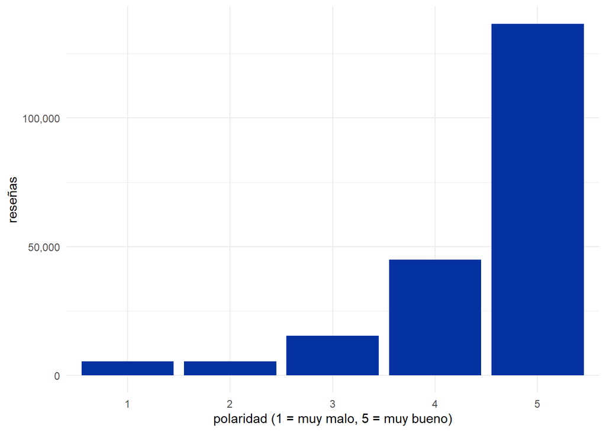

```r
resenas |>
  count(polaridad) |>
  ggplot(aes(factor(polaridad), n)) +
  geom_col(fill = "#0432a1") +
  scale_y_continuous(labels = scales::label_comma()) +
  labs(x = "polaridad (1 = muy malo, 5 = muy bueno)", y = "reseñas") +
  theme_minimal()
```

**Lo primero que salta:** dos de cada tres reseñas son un 5. Un modelo que diga “5” siempre acierta el 66% sin leer nada. Hay que tenerlo presente antes de celebrar cualquier *accuracy*.

# 3. ¿Cambia por tipo de lugar?

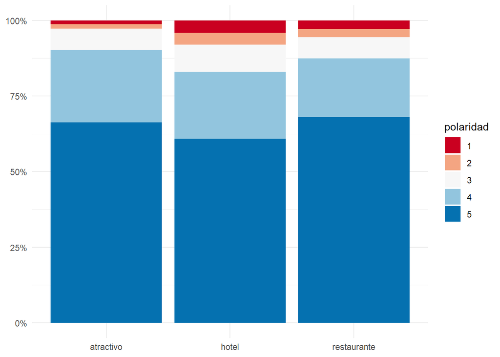

```r
resenas |>
  count(tipo, polaridad) |>
  group_by(tipo) |>
  mutate(proporcion = n / sum(n)) |>
  ggplot(aes(tipo, proporcion, fill = factor(polaridad))) +
  geom_col() +
  scale_fill_brewer(palette = "RdBu", name = "polaridad") +
  scale_y_continuous(labels = scales::label_percent()) +
  labs(x = NULL, y = NULL) +
  theme_minimal()
```

Los hoteles se quejan más que los atractivos.

# 4. ¿Las quejas son más largas?

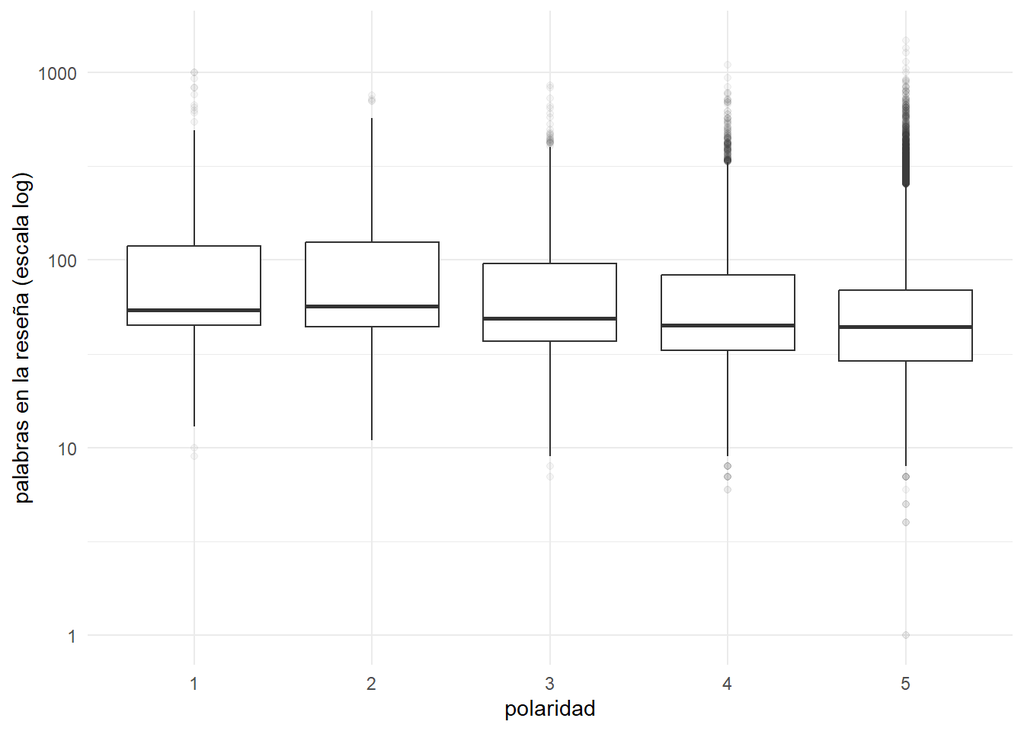

```r
resenas |>
  ggplot(aes(factor(polaridad), n_palabras)) +
  geom_boxplot(outlier.alpha = 0.05) +
  scale_y_log10() +
  labs(x = "polaridad", y = "palabras en la reseña (escala log)") +
  theme_minimal()
```

```r
resenas |>
  group_by(polaridad) |>
  summarise(mediana_palabras = median(n_palabras))
```

```
# A tibble: 5 × 2
  polaridad mediana_palabras
      <int>            <dbl>
1         1               54
2         2               57
3         3               49
4         4               45
5         5               44
```

# 5. Los pueblos

```r
resenas |>
  group_by(pueblo) |>
  summarise(resenas = n(), polaridad_media = mean(polaridad)) |>
  arrange(desc(resenas))
```

```
# A tibble: 40 × 3
   pueblo                     resenas polaridad_media
   <chr>                        <int>           <dbl>
 1 Tulum                        45334            4.54
 2 Isla Mujeres                 29824            4.52
 3 San Cristobal de las Casas   12956            4.47
 4 Valladolid                   11577            4.47
 5 Bacalar                      10822            4.54
 6 Palenque                      9505            4.44
 7 Sayulita                      7336            4.42
 8 Valle de Bravo                5959            4.36
 9 Teotihuacan                   5798            4.58
10 Loreto                        5524            4.56
# ℹ 30 more rows
```

# 6. ¿Qué palabras separan una queja de un elogio?

Se toma una muestra de 20 mil reseñas (con todas tarda y no cambia la historia), se parte en palabras con `tokenizar()` y se compara qué tan seguido aparece cada una en las reseñas de 1 a 3 contra las de 4 y 5.

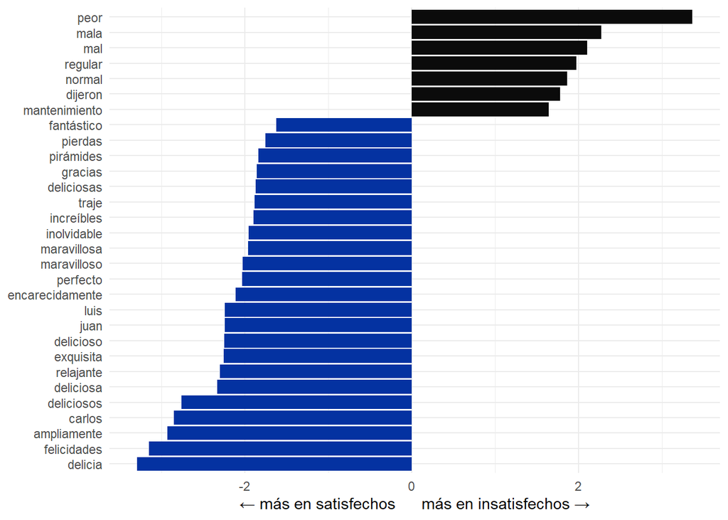

```r
set.seed(2025)

palabras <- resenas |>
  slice_sample(n = 20000) |>
  select(id, satisfecho, resena) |>
  tokenizar() |>
  distinct(id, satisfecho, palabra) |>          # cuenta reseñas, no repeticiones
  count(satisfecho, palabra) |>
  pivot_wider(names_from = satisfecho, values_from = n, values_fill = 0) |>
  filter(si + no >= 100) |>
  mutate(log_razon = log((no + 1) / sum(no)) - log((si + 1) / sum(si)))

palabras |>
  slice_max(abs(log_razon), n = 30) |>
  ggplot(aes(log_razon, fct_reorder(palabra, log_razon), fill = log_razon > 0)) +
  geom_col(show.legend = FALSE) +
  scale_fill_manual(values = c("#0432a1", "#0b0b0b")) +
  labs(x = "← más en satisfechos      más en insatisfechos →", y = NULL) +
  theme_minimal()
```

Las palabras “vacías” (*de*, *la*, *que*) salen solas: aparecen igual en los dos grupos, así que su razón es cercana a cero y nunca llegan al top. No hizo falta una lista de *stopwords*.

# Lo que me llevo al modelo

- Hay que **definir la variable respuesta**: cinco clases muy desbalanceadas. Para un primer modelo, satisfecho (4–5) contra no satisfecho (1–3): 87% contra 13%. La decisión quedó escrita **una vez**, en `scripts/02_limpiar.R`: es la columna `satisfecho` que ya usaron las secciones de arriba.
- La **longitud** y el **tipo de lugar** dicen algo.
- Las **palabras** dicen mucho más. Pero el vocabulario se escoge con los datos de entrenamiento, no con todos, o el modelo hace trampa.